# Network Properties

## Density

Network density describes the portion of potential connections in a network to actual connections.

- Potential connections is every previous node (because unidirectional connections with time)
  $$\frac{n(n+1)}{2}$$
- Actual connections is simply a count of number of citations.

## Size

Can refer to number of nodes (count patents) or sometimes number of edges (count citations).

## Average Degree

The degree of a node is the number of edges connected to it. This is the main thing we have already studied. We can compare this to a random graph model where average degree is p(N-1) where p is the probability of two nodes connecting.

## Average path length (characteristic path length)

The path length is the shortest path between a pair of nodes. The average therefore calculates this for all pairs of nodes and divides by the total number of pairs. **This doesn’t seem plausible to calculated**

## Diameter

This is the longest of all calculated shortest paths. For the same reasons as above (having to caulcate every permutation of node distances 100000!) this also **not plausible**

## Node influentce

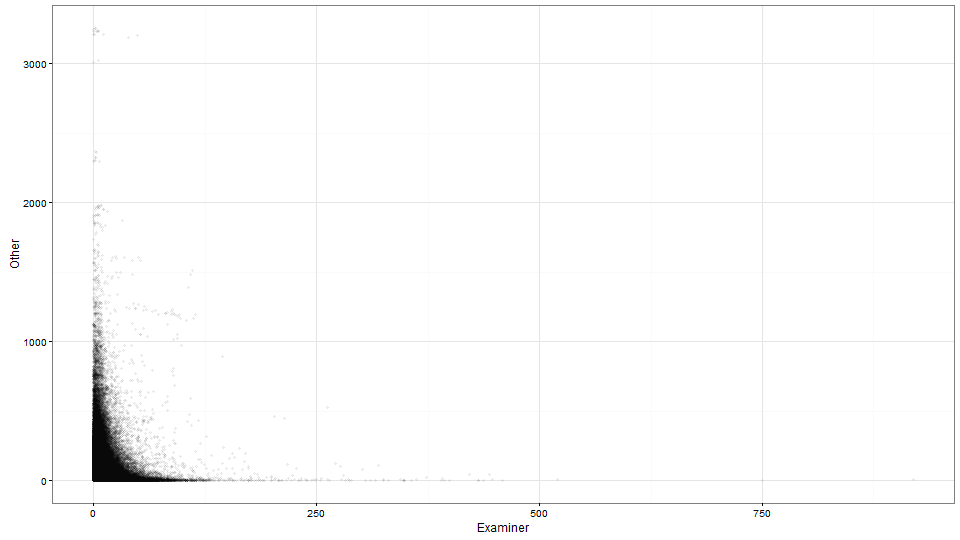